# R Notebook

# Overview of the dataset

The dataset is provides information about: - the quantity sold - the item sold - the category to which belong the item - the store where is sold the item - date on which is sold

The objective of the code challenge is to forecast the quantity sold for each item. Given that there is no specific request to forecast the quantity sold for a specific store, I would first exclude this variable as interesting for our analysis. The category could be of interest because we may expect that item belonging to the same category have similar economics (such us price, amount of sales), and so we could maybe use the same model for item belonging to the same category. However, we have not enough information about the logic behing the category and we have to predict the storage for only 10 items.Given this evidence, I have decided to exclude also this variable as of interest for our analysis ( I have only included this information for plotting the quantity time series). This information could be very useful in case we have to predict a very large number of items and creating an ad-hoc model for each item wouldn’t be feasible.

The only relevant variable is therefore, the historical quantity for each item at each date. As a consequence, I have decided to use ARIMA model to forecast the quantity.

Some additional information which could be useful, is maybe the “number of clients” for each store, which could be useful to predict the sales in case of opening new stores selling the same item. In this case it could be maybe possible create a relation between item sold and dimension of the store, having a more complete model that can predict item sold in case of opening new store.

# Selecting 10 item to predict

I have identified for each item: - number of data points - price making an average of those i have identified the 10 most important items. This indicator allows first to identify the most complete time series (number of data points). In addition, give priority to item which are more expensive, which can potentially lead to higher cost for non-optimal storage (i.e. by missing revenue for understorage or higher stock cost for overstorage)

```r
library(zoo)
library(dplyr)
library(bsts)
```

First, I have included the data from csv to dataframes.

```r
setAs("character","myDate", function(from) as.Date(from, format="%d/%m/%Y") )
```

```
in method for 㤼㸱coerce㤼㸲 with signature 㤼㸱"character","myDate"㤼㸲: no definition for class 㤼㸳myDate㤼㸴
```

```r
df_sales = read.csv("C:/Users/tolom/OneDrive/Desktop/Code Challenge/Evo/test/sales_data.csv", header=TRUE,fileEncoding="UTF-8-BOM",
                    colClasses = c("myDate", "integer", "integer", "integer", "integer", "integer"))
df_store = read.csv("C:/Users/tolom/OneDrive/Desktop/Code Challenge/Evo/test/store_master.csv", header=TRUE, sep=";", fileEncoding="UTF-8-BOM")
df_sales
```

| date | store | item | qty | unit_price | item_category |
| --- | --- | --- | --- | --- | --- |
| 2017-07-05 | 43 | 43 | 61 | 1008 | 13 |
| 2018-01-20 | 43 | 295 | 73 | 133 | 13 |
| 2017-07-10 | 43 | 296 | 145 | 119 | 13 |
| 2017-07-01 | 43 | 295 | 255 | 133 | 13 |
| 2017-05-23 | 43 | 43 | 267 | 1008 | 13 |
| 2017-06-24 | 43 | 43 | 242 | 1008 | 13 |
| 2017-03-23 | 43 | 43 | 200 | 1008 | 13 |
| 2018-01-19 | 43 | 296 | 121 | 119 | 13 |
| 2017-03-22 | 43 | 296 | 48 | 119 | 13 |
| 2017-09-02 | 43 | 43 | 182 | 1008 | 13 |

[output cut: 990 more lines]

```r
df_store
```

| store | latitude | longitude |
| --- | --- | --- |
| 12 | 51206599 | -1596419 |
| 13 | 51118627 | -2967112 |
| 14 | 52191839 | -1415261 |
| 15 | 51356004 | 67046 |
| 16 | 51022622 | 912628 |
| 31 | 50884434 | -959582 |
| 32 | 53183743 | -291991 |
| 38 | 51112151 | 31907 |
| 40 | 51232125 | 11081 |
| 41 | 52063213 | -199684 |

[output cut: 38 more lines]

Then, I have manipulated the dataframe “df_sales” to create the metric i need to decide which item storage predict. The metric is stored in the column “metric_choice” and is:

```
                  (Number of data points available for item + Price of item)/ 2
```

```r
new_df_sales <- df_sales %>%
   group_by(date, item) %>%
   summarise(qty = sum(qty), price = mean(unit_price))
new_df_sales
```

| date | item | qty | price |
| --- | --- | --- | --- |
| 2017-03-15 | 43 | 1230 | 1008.0000 |
| 2017-03-15 | 44 | 196 | 378.0000 |
| 2017-03-15 | 48 | 611 | 6608.0000 |
| 2017-03-15 | 70 | 443 | 1002.1667 |
| 2017-03-15 | 73 | 782 | 3255.0000 |
| 2017-03-15 | 75 | 629 | 2723.0000 |
| 2017-03-15 | 76 | 861 | 2555.6667 |
| 2017-03-15 | 78 | 425 | 606.5000 |
| 2017-03-15 | 79 | 527 | 1103.0000 |
| 2017-03-15 | 108 | 641 | 2884.0000 |

[output cut: 990 more lines]

```r
final_df_sales <- new_df_sales %>%
   group_by(item) %>%
   summarise(qty = sum(qty), DataPoints = n(), price = mean(price),
             metric_choice = (DataPoints + price)/2)
final_df_sales1 <- final_df_sales[rev(order(final_df_sales$metric_choice)), ]
final_df_sales1
```

| item | qty | DataPoints | price | metric_choice |
| --- | --- | --- | --- | --- |
| 48 | 438037 | 744 | 6545.8844 | 3644.9422 |
| 127 | 513132 | 708 | 4566.5042 | 2637.2521 |
| 165 | 455634 | 742 | 4131.2173 | 2436.6087 |
| 139 | 351744 | 742 | 3713.6226 | 2227.8113 |
| 234 | 358530 | 686 | 3686.8163 | 2186.4082 |
| 120 | 309477 | 541 | 3795.1645 | 2168.0823 |
| 231 | 284503 | 738 | 3575.9153 | 2156.9577 |
| 410 | 588320 | 717 | 3550.0251 | 2133.5126 |
| 147 | 414920 | 560 | 3576.3302 | 2068.1651 |
| 76 | 500284 | 542 | 3435.5117 | 1988.7558 |

[output cut: 73 more lines]

Below we can find the list of item choosen.

```r
list_of_item_to_predict = as.vector(t(final_df_sales1[1:10, "item"]))
list_of_item_to_predict
```

```
 [1]  48 127 165 139 234 120 231 410 147  76
```

I have created a subset of the original df_sales including only the data for the selected items.

```r
df_sales_for_model = df_sales[df_sales$item %in% list_of_item_to_predict, ]
df_sales_for_model
```

|  | date | store | item | qty | unit_price | item_category |
| --- | --- | --- | --- | --- | --- | --- |
| 128 | 2017-11-12 | 52 | 231 | 115 | 3853 | 19 |
| 129 | 2017-06-26 | 52 | 231 | 145 | 365 | 19 |
| 130 | 2018-10-12 | 52 | 231 | 124 | 3892 | 19 |
| 160 | 2017-11-01 | 52 | 76 | 121 | 3493 | 13 |
| 161 | 2018-01-24 | 52 | 76 | 115 | 3493 | 13 |
| 162 | 2017-10-31 | 52 | 76 | 121 | 3493 | 13 |
| 163 | 2018-02-24 | 52 | 120 | 73 | 3941 | 13 |
| 164 | 2017-11-13 | 52 | 120 | 36 | 3941 | 13 |
| 165 | 2018-07-02 | 52 | 120 | 115 | 3941 | 13 |
| 166 | 2018-09-12 | 52 | 120 | 105 | 3941 | 13 |

[output cut: 990 more lines]

I have grouped the quantity across all the stores for each date, in order to get a time series of the historical total storage per item.

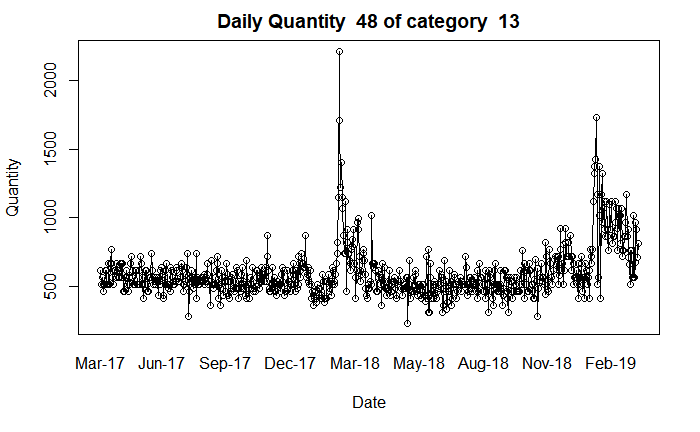

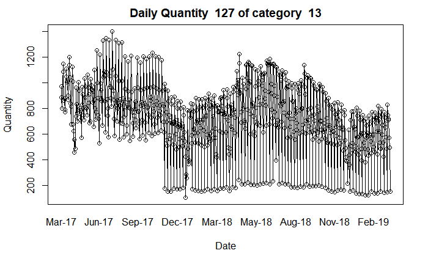

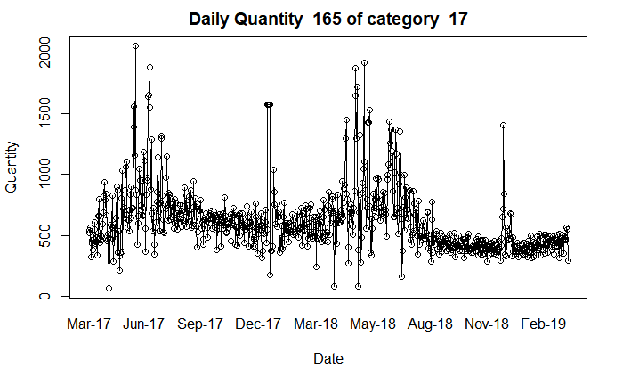

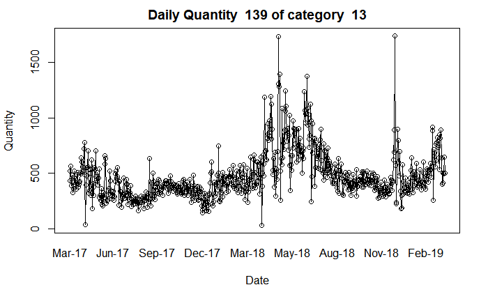

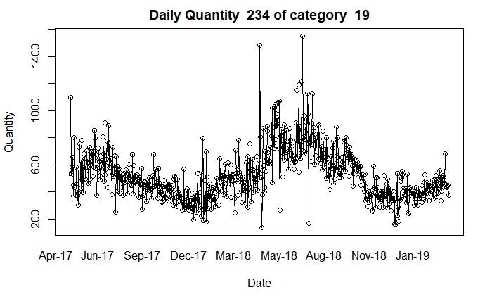

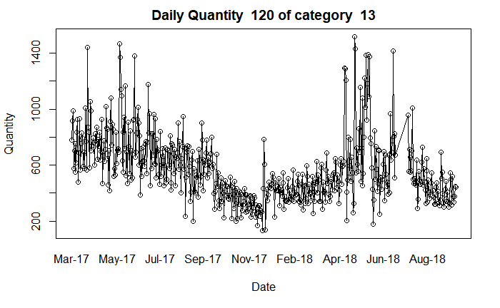

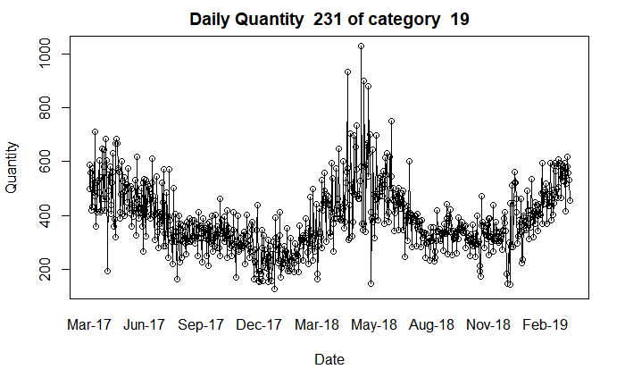

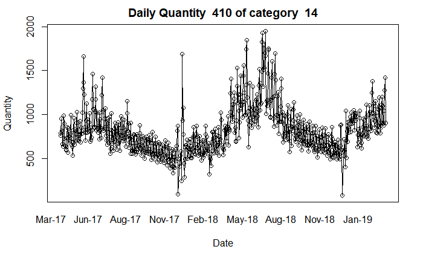

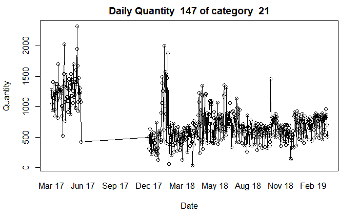

```r
df_groupby_item_date_daily <- df_sales_for_model %>%
   group_by(item, date) %>%
   summarise(qty = sum(qty))

for (item in list_of_item_to_predict)
  {
    t = as.Date(as.vector(t(df_groupby_item_date_daily[df_groupby_item_date_daily$item == item, "date"])))
    q = as.vector(t(df_groupby_item_date_daily[df_groupby_item_date_daily$item == item, "qty"]))
    title = paste("Daily Quantity ", item, "of category ", df_sales_for_model[df_sales_for_model$item == item, "item_category"][1])
    plot(t, q, type="o",  main=title, xaxt="n", xlab="Date", ylab="Quantity")
    axis.Date(1, at=df_groupby_item_date_daily$date, format="%b-%y", tcl=0)
}
```

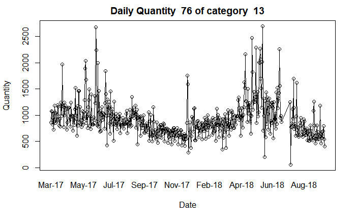

```r
NA
```

# The Model

As a model prediction I have used an ARIMA model. This choice is the best given the dataset, since we have only the historical sold quantity for each item.

I couldn’t consider the case when a new store is open (because of missing information), so my assumption is that the store selling the item are constant throught the forecasting period in terms of size and number.

The model uses daily time series and is constructed with the following steps: - time series relevant for the item are selected - the time series is cleaned by removing the points where we have 3 or more consecutive missing values and by linearly interpolating the other missing values (where we have less than 3 consecutive missing values) - holiday effect are taken in account calibrating the fourier terms for the ARIMA model. The fourier term is calibrated such that the AICc is minimized - the model is calibrated on the whole time series removing the last 30 days. This is the trianing set of the model - The test set is the last 30 days of the time series - The model is evaluated using the MAPE (Mean Average Percentage Error). This measure is easy to understand because it provides the error in terms of percentages. Also, because absolute percentage errors are used, the problem of positive and negative errors canceling each other out is avoided.

The code creates the following output for each item: - a dataframe with the forecasted data (columns Date/Value) - a line plot highlighting the forecast time series - a summary of the ARIMA model calibrated - the optimal fourier term for holiday effects

```
[1] 5
[1] "Summary data for  48"
Series: ts(ts_data, frequency = frequency)
Regression with ARIMA(1,0,1) errors

Coefficients:
         ar1      ma1  intercept    S1-365   C1-365    S2-365   C2-365    S3-365   C3-365
      0.7266  -0.3120   597.9777  -60.8418  90.9511  -61.2542  36.6696  -45.0644  21.3103
s.e.  0.0517   0.0737    11.8584   16.0884  16.3400   16.0367  16.2648   15.9528  16.1412
        S4-365   C4-365    S5-365    C5-365   holiday
      -54.7983  -5.9790  -41.6029  -25.3534  -45.9058
s.e.   15.8313  15.9737   15.6792   15.7694    9.6335

sigma^2 estimated as 15256:  log likelihood=-4457.59
AIC=8945.17   AICc=8945.86   BIC=9013.78

Training set error measures:
                    ME     RMSE      MAE       MPE     MAPE      MASE        ACF1
Training set 0.1472245 122.3033 80.71063 -3.459514 14.18577 0.6726604 0.009615608
[1] "Forecast data for  48"
```

```
xreg contains different column names from the xreg used in training. Please check that the regressors are in the same order.
```

| time_vector_forecast | fcast.mean |
| --- | --- |
| 2019-03-30 | 937.2933 |
| 2019-03-31 | 898.1642 |
| 2019-04-01 | 912.4997 |
| 2019-04-02 | 886.3100 |
| 2019-04-03 | 863.9334 |
| 2019-04-04 | 844.2461 |
| 2019-04-05 | 826.4470 |
| 2019-04-06 | 764.0641 |
| 2019-04-07 | 748.5131 |
| 2019-04-08 | 779.5221 |

[output cut: 20 more lines]

```
[1] " "
[1] "MAPE for item  48 :  0.17428696184845"
[1] 4
[1] "Summary data for  127"
Series: ts(ts_data, frequency = frequency)
Regression with ARIMA(2,1,3) errors

Coefficients:
          ar1      ar2      ma1     ma2      ma3    S1-365    C1-365   S2-365   C2-365
      -0.4718  -0.8751  -0.2644  0.1919  -0.8917  123.2072  -50.7578  24.8851  14.9457
s.e.   0.0248   0.0265   0.0333  0.0313   0.0176   17.1161   15.3571  13.3133  13.0048
        S3-365   C3-365   S4-365   C4-365   holiday
      -22.7497  15.5418  25.2451  -1.8857  -35.4744
s.e.   12.5165  12.4987  12.2320  12.2906   20.2261

sigma^2 estimated as 42092:  log likelihood=-4816.55
AIC=9663.09   AICc=9663.78   BIC=9731.68

Training set error measures:
                   ME     RMSE      MAE       MPE     MAPE      MASE       ACF1
Training set -17.5486 203.0018 166.8084 -20.40723 36.83868 0.7905983 0.03627485
[1] "Forecast data for  127"
```

| time_vector_forecast | fcast.mean |
| --- | --- |
| 2019-03-30 | 553.8607 |
| 2019-03-31 | 482.5326 |
| 2019-04-01 | 699.6853 |
| 2019-04-02 | 684.5516 |
| 2019-04-03 | 540.9573 |
| 2019-04-04 | 630.2837 |
| 2019-04-05 | 722.2005 |
| 2019-04-06 | 573.6388 |
| 2019-04-07 | 555.0415 |
| 2019-04-08 | 706.7604 |

[output cut: 20 more lines]

```
[1] " "
[1] "MAPE for item  127 :  0.637747108327741"
```

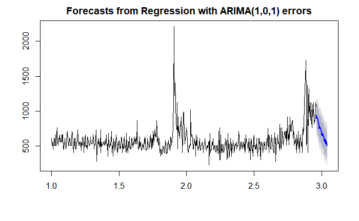

```
[1] 2
[1] "Summary data for  165"
Series: ts(ts_data, frequency = frequency)
Regression with ARIMA(2,1,3) errors

Coefficients:
         ar1      ar2      ma1     ma2      ma3    S1-365   C1-365   S2-365    C2-365
      0.9769  -0.6547  -1.5631  1.1755  -0.5889  161.2503   9.7910   8.6028  -98.2291
s.e.  0.0677   0.0551   0.0658  0.0936   0.0550   26.9113  24.3504  18.2382   17.6050
       holiday
      -97.7498
s.e.   15.9467

sigma^2 estimated as 34471:  log likelihood=-4746.06
AIC=9514.12   AICc=9514.49   BIC=9564.41

Training set error measures:
                     ME     RMSE      MAE       MPE     MAPE      MASE       ACF1
Training set -0.7124284 184.2317 122.9229 -9.891552 24.14165 0.5261381 0.04297953
[1] "Forecast data for  165"
```

```
xreg contains different column names from the xreg used in training. Please check that the regressors are in the same order.
```

| time_vector_forecast | fcast.mean |
| --- | --- |
| 2019-03-30 | 341.2373 |
| 2019-03-31 | 367.7104 |
| 2019-04-01 | 471.4747 |
| 2019-04-02 | 461.1865 |
| 2019-04-03 | 448.4473 |
| 2019-04-04 | 444.0680 |
| 2019-04-05 | 449.5402 |
| 2019-04-06 | 361.4929 |
| 2019-04-07 | 368.9576 |
| 2019-04-08 | 469.2963 |

[output cut: 20 more lines]

```
[1] " "
[1] "MAPE for item  165 :  0.137117153245068"
```

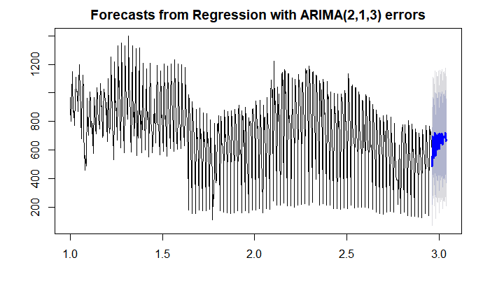

```
[1] 1
[1] "Summary data for  139"
Series: ts(ts_data, frequency = frequency)
Regression with ARIMA(1,1,4) errors

Coefficients:
          ar1     ma1      ma2      ma3      ma4    S1-365   C1-365   holiday
      -0.7934  0.2698  -0.6580  -0.2085  -0.1857  109.1779  55.4912  -60.8462
s.e.   0.0602  0.0684   0.0489   0.0489   0.0392   52.8924  50.3152   10.7632

sigma^2 estimated as 17887:  log likelihood=-4511.93
AIC=9041.86   AICc=9042.11   BIC=9083.01

Training set error measures:
                    ME     RMSE      MAE      MPE     MAPE      MASE        ACF1
Training set 0.8903178 132.8985 85.37317 -8.79852 23.03878 0.3843985 0.003803556
[1] "Forecast data for  139"
```

```
xreg contains different column names from the xreg used in training. Please check that the regressors are in the same order.
```

| time_vector_forecast | fcast.mean |
| --- | --- |
| 2019-03-30 | 478.5661 |
| 2019-03-31 | 443.6940 |
| 2019-04-01 | 522.6147 |
| 2019-04-02 | 503.8556 |
| 2019-04-03 | 522.3583 |
| 2019-04-04 | 511.2792 |
| 2019-04-05 | 523.6494 |
| 2019-04-06 | 456.5480 |
| 2019-04-07 | 465.0475 |
| 2019-04-08 | 522.6637 |

[output cut: 20 more lines]

```
[1] " "
[1] "MAPE for item  139 :  0.267889799283161"
```

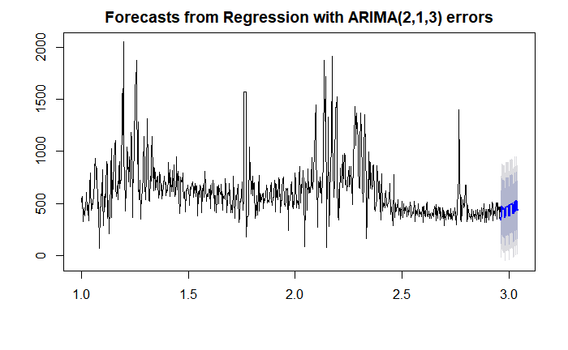

```
[1] 5
[1] "Summary data for  234"
Series: ts(ts_data, frequency = frequency)
Regression with ARIMA(2,1,3) errors

Coefficients:
          ar1      ar2     ma1      ma2      ma3    S1-365    C1-365   S2-365   C2-365
      -0.9632  -0.7462  0.0644  -0.1416  -0.8062  143.0516  103.2678  23.0546  -1.1043
s.e.   0.0994   0.1042  0.0821   0.1057   0.0797   19.8149   19.1640  11.8235  11.5085
       S3-365   C3-365    S4-365  C4-365   S5-365   C5-365   holiday
      29.9963  -3.2821  -14.2639  7.6553  -0.0645  27.3935  -34.7973
s.e.   9.6898   9.2606    8.5183  8.5176   8.0607   7.9283   10.6074

sigma^2 estimated as 15671:  log likelihood=-4129.83
AIC=8293.66   AICc=8294.61   BIC=8370.08

Training set error measures:
                    ME     RMSE      MAE       MPE     MAPE    MASE       ACF1
Training set 0.8937541 123.5681 84.77854 -5.096588 17.84715 0.51944 0.01157659
[1] "Forecast data for  234"
```

```
xreg contains different column names from the xreg used in training. Please check that the regressors are in the same order.
```

| time_vector_forecast | fcast.mean |
| --- | --- |
| 2019-03-30 | 396.8173 |
| 2019-03-31 | 386.8767 |
| 2019-04-01 | 427.5428 |
| 2019-04-02 | 426.3003 |
| 2019-04-03 | 419.9705 |
| 2019-04-04 | 423.7546 |
| 2019-04-05 | 421.5478 |
| 2019-04-06 | 382.7711 |
| 2019-04-07 | 385.0248 |
| 2019-04-08 | 417.5011 |

[output cut: 20 more lines]

```
[1] " "
[1] "MAPE for item  234 :  0.125232807378527"
```

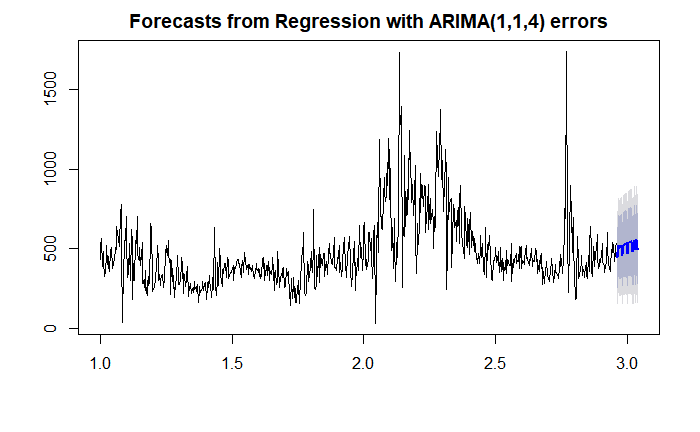

```
[1] 1
[1] "Summary data for  120"
Series: ts(ts_data, frequency = frequency)
Regression with ARIMA(3,1,2) errors

Coefficients:
          ar1     ar2     ar3      ma1      ma2    S1-365   C1-365   holiday
      -0.6427  0.2773  0.1285  -0.0781  -0.8596  187.0906  50.2513  -61.3109
s.e.   0.0717  0.0649  0.0491   0.0579   0.0532   41.3719  37.3179   16.8979

sigma^2 estimated as 33439:  log likelihood=-3410.28
AIC=6838.56   AICc=6838.91   BIC=6876.75

Training set error measures:
                    ME     RMSE      MAE       MPE     MAPE      MASE         ACF1
Training set -10.75074 181.2612 132.0246 -11.42685 25.95874 0.4698663 0.0005896033
[1] "Forecast data for  120"
```

```
xreg contains different column names from the xreg used in training. Please check that the regressors are in the same order.
```

| time_vector_forecast | fcast.mean |
| --- | --- |
| 2018-09-28 | 415.8693 |
| 2018-09-29 | 383.6345 |
| 2018-09-30 | 387.7996 |
| 2018-10-01 | 462.9183 |
| 2018-10-02 | 454.8965 |
| 2018-10-03 | 460.3652 |
| 2018-10-04 | 452.3363 |
| 2018-10-05 | 453.9076 |
| 2018-10-06 | 385.9779 |
| 2018-10-07 | 385.5421 |

[output cut: 20 more lines]

```
[1] " "
[1] "MAPE for item  120 :  0.208393485453798"
```

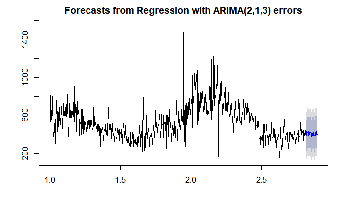

```
[1] 4
[1] "Summary data for  231"
Series: ts(ts_data, frequency = frequency)
Regression with ARIMA(2,1,3) errors

Coefficients:
          ar1      ar2     ma1      ma2      ma3   S1-365   C1-365   S2-365  C2-365
      -0.9694  -0.6794  0.1012  -0.1606  -0.8127  95.0934  59.3467  39.4621  3.2680
s.e.   0.0589   0.0811  0.0422   0.0627   0.0581  14.2101  12.9817   8.1179  7.7006
       S3-365  C3-365  S4-365  C4-365   holiday
      -3.5014  1.3377  9.6020  3.1752  -31.2607
s.e.   6.3925  6.2409  5.6725  5.6296    6.7824

sigma^2 estimated as 6885:  log likelihood=-4168.03
AIC=8366.06   AICc=8366.75   BIC=8434.65

Training set error measures:
                   ME     RMSE      MAE       MPE    MAPE      MASE        ACF1
Training set 1.243935 82.09975 58.30588 -4.230485 16.5491 0.5484046 -0.02270353
[1] "Forecast data for  231"
```

```
xreg contains different column names from the xreg used in training. Please check that the regressors are in the same order.
```

| time_vector_forecast | fcast.mean |
| --- | --- |
| 2019-03-30 | 472.9570 |
| 2019-03-31 | 461.0163 |
| 2019-04-01 | 491.0345 |
| 2019-04-02 | 509.8901 |
| 2019-04-03 | 502.0355 |
| 2019-04-04 | 506.4496 |
| 2019-04-05 | 517.1326 |
| 2019-04-06 | 482.1458 |
| 2019-04-07 | 488.1197 |
| 2019-04-08 | 525.7170 |

[output cut: 20 more lines]

```
[1] " "
[1] "MAPE for item  231 :  0.0996647660071059"
```

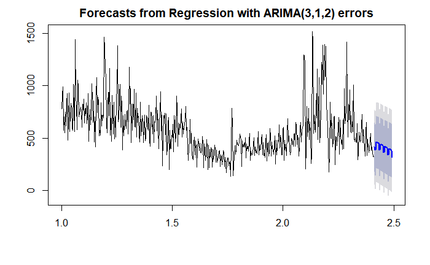

```
[1] 1
[1] "Summary data for  410"
Series: ts(ts_data, frequency = frequency)
Regression with ARIMA(4,1,1) errors

Coefficients:
         ar1      ar2      ar3      ar4      ma1    S1-365    C1-365   holiday
      0.2405  -0.0940  -0.2122  -0.2368  -0.7073  254.5966  100.9117  -98.2372
s.e.  0.0575   0.0391   0.0399   0.0455   0.0516  113.4132  108.1095   13.9147

sigma^2 estimated as 24821:  log likelihood=-4492.85
AIC=9003.7   AICc=9003.96   BIC=9044.58

Training set error measures:
                   ME     RMSE      MAE       MPE     MAPE      MASE       ACF1
Training set 2.619938 156.5233 121.2614 -3.843456 16.76853 0.4849486 -0.0191798
[1] "Forecast data for  410"
```

```
xreg contains different column names from the xreg used in training. Please check that the regressors are in the same order.
```

| time_vector_forecast | fcast.mean |
| --- | --- |
| 2019-03-30 | 1080.7717 |
| 2019-03-31 | 1018.0785 |
| 2019-04-01 | 1016.4635 |
| 2019-04-02 | 963.5377 |
| 2019-04-03 | 996.3489 |
| 2019-04-04 | 1051.3062 |
| 2019-04-05 | 1102.3892 |
| 2019-04-06 | 1022.9287 |
| 2019-04-07 | 1009.3088 |
| 2019-04-08 | 1084.7594 |

[output cut: 20 more lines]

```
[1] " "
[1] "MAPE for item  410 :  0.160873081715432"
```

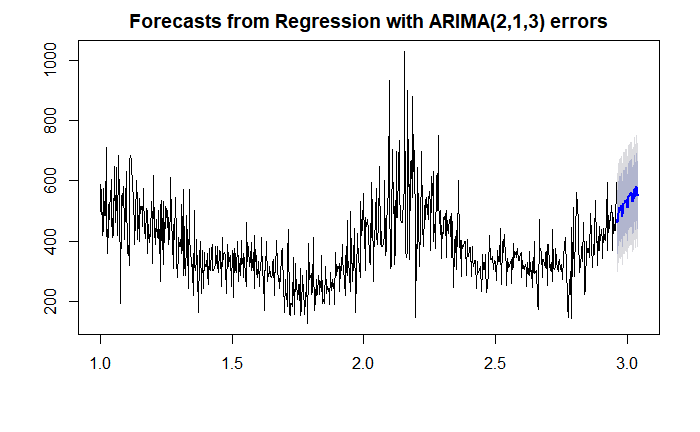

```
[1] 1
[1] "Summary data for  147"
Series: ts(ts_data, frequency = frequency)
Regression with ARIMA(1,1,2) errors

Coefficients:
          ar1      ma1      ma2    S1-365    C1-365   holiday
      -0.6086  -0.0168  -0.6268  -81.3681  113.8482  -52.1720
s.e.   0.1008   0.0854   0.0600  190.6907  182.9806   21.7914

sigma^2 estimated as 55502:  log likelihood=-3665.05
AIC=7344.1   AICc=7344.32   BIC=7374.05

Training set error measures:
                    ME     RMSE      MAE       MPE     MAPE      MASE       ACF1
Training set -1.353905 234.0397 169.9907 -14.29904 31.82359 0.3810895 0.01133433
[1] "Forecast data for  147"
```

```
xreg contains different column names from the xreg used in training. Please check that the regressors are in the same order.
```

| time_vector_forecast | fcast.mean |
| --- | --- |
| 2019-03-30 | 769.6237 |
| 2019-03-31 | 707.7494 |
| 2019-04-01 | 799.1511 |
| 2019-04-02 | 776.9096 |
| 2019-04-03 | 792.1395 |
| 2019-04-04 | 784.6241 |
| 2019-04-05 | 791.0106 |
| 2019-04-06 | 736.8229 |
| 2019-04-07 | 739.9788 |
| 2019-04-08 | 792.2168 |

[output cut: 20 more lines]

```
[1] " "
[1] "MAPE for item  147 :  0.14543491494743"
```

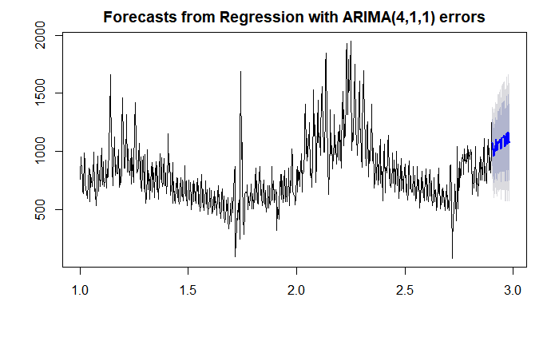

```
[1] 3
[1] "Summary data for  76"
Series: ts(ts_data, frequency = frequency)
Regression with ARIMA(4,0,1) errors

Coefficients:
          ar1     ar2     ar3      ar4     ma1  intercept    S1-365   C1-365   S2-365
      -0.5870  0.2643  0.0799  -0.0931  0.8203   931.4309  216.7400  83.1869  52.7586
s.e.   0.0724  0.0520  0.0509   0.0457  0.0593    18.9832   23.7664  24.5735  23.9467
        C2-365    S3-365   C3-365    holiday
      -30.1422  -10.9777  -75.221  -142.3481
s.e.   24.4020   23.6501   23.657    26.2817

sigma^2 estimated as 75615:  log likelihood=-3630.95
AIC=7289.9   AICc=7290.73   BIC=7349.37

Training set error measures:
                       ME     RMSE      MAE       MPE     MAPE      MASE       ACF1
Training set -0.002788168 271.5031 186.0988 -9.385009 23.42159 0.5303303 0.01074998
[1] "Forecast data for  76"
```

```
xreg contains different column names from the xreg used in training. Please check that the regressors are in the same order.
```

| time_vector_forecast | fcast.mean |
| --- | --- |
| 2018-09-29 | 692.9181 |
| 2018-09-30 | 745.7483 |
| 2018-10-01 | 905.2903 |
| 2018-10-02 | 901.1625 |
| 2018-10-03 | 901.1733 |
| 2018-10-04 | 896.8989 |
| 2018-10-05 | 897.9017 |
| 2018-10-06 | 754.6818 |
| 2018-10-07 | 755.6037 |
| 2018-10-08 | 898.1596 |

[output cut: 20 more lines]

```
[1] " "
[1] "MAPE for item  76 :  0.425803036574785"
```

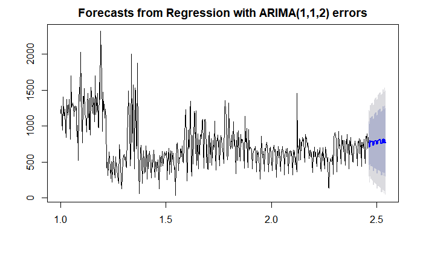

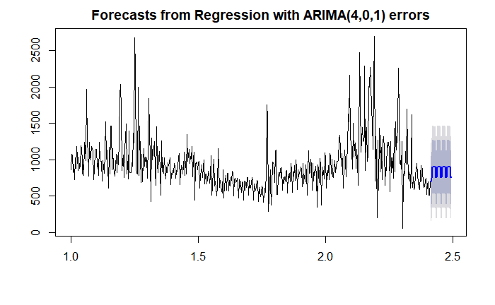

```r
library(forecast)
library(RQuantLib)
library(MLmetrics)

calibrate_k_fourier_term <- function(data, n) {
bestfit <- list(aicc=Inf)
for(i in 1:n)
{
  fit <- auto.arima(data, xreg=fourier(data, K=i), seasonal=FALSE)
    if(fit$aicc < bestfit$aicc)
    {
        bestfit <- fit
        bestk <- i
    }
    else
    {
    }
}
 return(bestk)
}


frequency = 365.25

for (item in list_of_item_to_predict)
  {
    data_single_item = df_groupby_item_date_daily[df_groupby_item_date_daily$item == item, ]
    time_vector <- seq(min(data_single_item$date), max(data_single_item$date), "1 day")
    new_df <- data.frame(date = time_vector) %>% full_join(data_single_item, by = "date")
    is.na.rle <- rle(is.na(new_df[, "qty"]))
    is.na.rle$values <- is.na.rle$values & is.na.rle$lengths >= 3
    new_df <- new_df[!inverse.rle(is.na.rle), ]
    new_df[,2] = na.approx(new_df[,2], method="linear")
    new_df[,3] = na.approx(new_df[,3], method="linear")
    ts_data <- xts(new_df[1:(nrow(new_df)-30), "qty"], as.Date(new_df[1:(nrow(new_df)-30), "date"], format='%m/%d/%Y'))
    k <- calibrate_k_fourier_term(ts(ts_data, frequency=frequency), 5)
    print(k)
    holiday <- isHoliday(calendar="Italy", dates=as.Date(new_df[1:(nrow(new_df)-30), "date"], format='%m/%d/%Y'))
    z <- fourier(ts(ts_data, frequency=frequency), K=k)

    fit<- auto.arima(ts(ts_data, frequency=frequency), xreg=cbind(z,holiday), seasonal=FALSE, stepwise=FALSE, approximation=FALSE)
    print(paste("Summary data for ", item))
    summary(fit)
    print(paste("Forecast data for ", item))

    time_vector_forecast <-  seq(max(time_vector), max(time_vector) + 29, "1 day")
    holidayf <- isHoliday(calendar="Italy", dates=time_vector_forecast)
    zf <- fourier(ts(ts_data, frequency=frequency), K=k, h=30)
    fcast <- forecast(fit, h=30,  xreg=cbind(zf,holidayf))
    x = data.frame(time_vector_forecast, fcast$mean)
    print(x)
    print(" ")
    fcast_to_print <- xts(fcast$mean, time_vector_forecast)
    print(paste("MAPE for item ", item, ": ", MAPE(fcast$mean, new_df[(nrow(new_df)-29):nrow(new_df), "qty"])))
    plot(fcast)

  }
```